# HW5_Lentz

### Purpose: This notebook demonstrates the solution of linear programming problems using Python and Pulp

### Problems are from 'Introduction to Operations Research' Tenth Edition by Fredrick S. Hillier and Gerald J. Lieberman

##### References

http://coral.ie.lehigh.edu/~ted/files/talks/PythonModeling.pdf  
http://ksuweb.kennesaw.edu/~jgarrido/CS4491_notes/Sensitivity_rep.pdf

#### Problem 4.7-3

```python
# get your instance setup
import os
#os.system("brew install glpk") # or sudo apt install glpk on linux
#os.system("pip install pulp")
from pulp import *

prob = LpProblem("p4.7-3", LpMaximize)

# Variables, lower bounds added here
x1 = LpVariable("x1",lowBound=0)
x2 = LpVariable("x2",lowBound=0)
z = LpVariable("z", 0)

# Objective
prob += 4*x1 + 2*x2

# Constraints
prob += 2*x1 <= 16 # resource 1
prob += (1*x1 + 3*x2) <= 17 # resource 2
prob += x2 <= 5 # resource 3

# Solve using GLPK
GLPK().solve(prob)

# Solution
for v in prob.variables():
    print (v.name, "=", v.varValue)

print ("objective=", value(prob.objective) )
```

```
('x1', '=', 8.0)
('x2', '=', 3.0)
('objective=', 38.0)
```

[figure not shown]

```python
# Next, we will solve this problem graphically
%matplotlib inline
from matplotlib import pyplot as plt
from matplotlib.path import Path
from matplotlib.patches import PathPatch

# use seaborn to change the default graphics to something nicer
# and set a nice color palette
import seaborn as sns

# create the plot object
fig, ax = plt.subplots(figsize=(10, 10))
x1 = np.linspace(0, 10)
x2 = np.linspace(0, 10)

# add resource 1 constraint: prob += 2*x1 <= 16 # resource 1
plt.plot( 8 * np.ones_like(x1), x1, lw=3, label='resource 1' )
plt.fill_between( np.linspace(0, 8), 0, 100, alpha=0.1 )

# add resource 2 constraint: 1*x1+3*x2 <= 17 # resource 2
plt.plot(x1, 3*x2, lw=3, label='resource 2')
plt.fill_between(np.linspace(0, 17), 0, 17, alpha=0.1)

# add resource 3 constraint: x2 <= 5 # resource 3
plt.plot(x2, 5 * np.ones_like(x2), lw=3, label='resource 3')
plt.fill_between(x1, 0, 5, alpha=0.1)

# add non-negativity constraints
plt.plot(np.zeros_like(s), s, lw=3, label='x1 non-negative')
plt.plot(s, np.zeros_like(s), lw=3, label='x2 non-negative')

# highlight the feasible region
path = Path([
    (0., 0.),
    (1.65, 5.),
    (8., 5.),
    (8., 0.),
    (0., 0.),
])
patch = PathPatch(path, label='feasible region', alpha=0.5)
ax.add_patch(patch)

# labels and stuff
plt.xlabel('x1', fontsize=16)
plt.ylabel('x2', fontsize=16)
plt.xlim(-0.5, 10)
plt.ylim(-0.5, 10)
plt.legend(fontsize=14)
plt.show()
```

#### Problem 4.7-6c

```python
sensitivity_file_name = 'sensit1.sen'
prob = LpProblem("p4.7-6c", LpMaximize)

# Variables, lower bounds added here
x1 = LpVariable("x1",lowBound=0)
x2 = LpVariable("x2",lowBound=0)
x3 = LpVariable("x3",lowBound=0)
x4 = LpVariable("x4",lowBound=0)
z = LpVariable("z", 0)

# Objective
prob += 5*x1 + 4*x2 + -1*x3 + 3*x4, "Objective"

# Constraints
prob += 3*x1 +2*x2 -3*x3 + 1*x4 <= 24 , "resource constraint 1"
prob += 3*x1 +3*x2 +1*x3 + 3*x4 <= 36 , "resource constraint 2"

# save the linear program model
prob.writeLP("p4-7-6c.lp")

# Solve the optimization problem using the specified Solver
GLPK(options=['--ranges', sensitivity_file_name]).solve(prob)

# Solution
print ("Status:", LpStatus[prob.status])
for v in prob.variables():
    print (v.name, "=", v.varValue)

print ("objective=", value(prob.objective) )
```

```
('Status:', 'Optimal')
('x1', '=', 11.0)
('x2', '=', 0.0)
('x3', '=', 3.0)
('x4', '=', 0.0)
('objective=', 52.0)
```

Next we perform a review of the sensitivity analysis report. Before we look at the report, lets review what the column names mean.

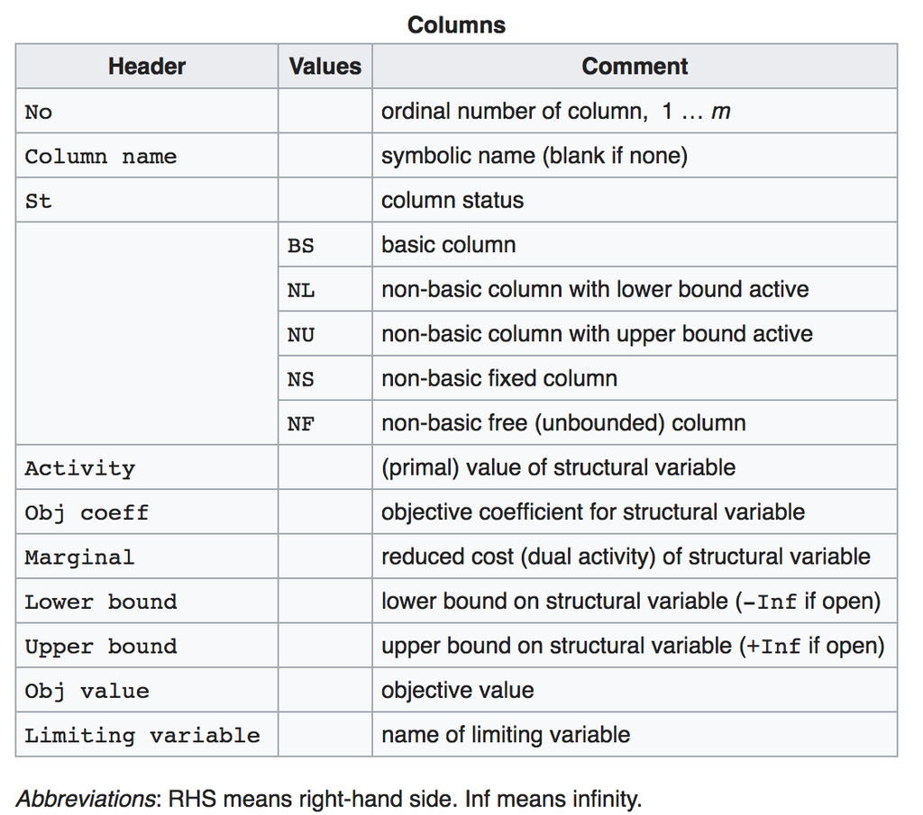

```python
from IPython.display import Image
Image(filename='sen.png')
```

```python
print('')
with open(sensitivity_file_name) as f:
    data = f.read()
    print(data)
```

```
GLPK 4.63 - SENSITIVITY ANALYSIS REPORT                                                                         Page   1

Problem:
Objective:  Objective = 52 (MAXimum)

   No. Row name     St      Activity         Slack   Lower bound       Activity      Obj coef  Obj value at Limiting
                                          Marginal   Upper bound          range         range   break point variable
------ ------------ -- ------------- ------------- -------------  ------------- ------------- ------------- ------------
     1 resource_constraint_1
                    NU      24.00000        .               -Inf     -108.00000       -.66667     -36.00000 x1
                                            .66667      24.00000       36.00000          +Inf      60.00000 x3

     2 resource_constraint_2
                    NU      36.00000        .               -Inf       24.00000      -1.00000      40.00000 x3
                                           1.00000      36.00000           +Inf          +Inf          +Inf

GLPK 4.63 - SENSITIVITY ANALYSIS REPORT                                                                         Page   2

Problem:
Objective:  Objective = 52 (MAXimum)

   No. Column name  St      Activity      Obj coef   Lower bound       Activity      Obj coef  Obj value at Limiting
                                          Marginal   Upper bound          range         range   break point variable
------ ------------ -- ------------- ------------- -------------  ------------- ------------- ------------- ------------
     1 x1           BS      11.00000       5.00000        .              .            4.63636      48.00000 x2
                                            .               +Inf       11.00000          +Inf          +Inf

     2 x2           NL        .            4.00000        .                -Inf          -Inf          +Inf
                                           -.33333          +Inf       12.00000       4.33333      48.00000 x1

     3 x3           BS       3.00000      -1.00000        .            -3.60000      -2.33333      48.00000 x4
                                            .               +Inf       36.00000       1.66667      60.00000 resource_constraint_1

     4 x4           NL        .            3.00000        .                -Inf          -Inf          +Inf
                                           -.66667          +Inf        6.00000       3.66667      48.00000 x3

End of report
```

A one unit increase in resource_constraint_1 increases z by .66667  
A one unit increase in resource_constraint_2 increases z by 1.00000  
Thus the shadow prices are .66667 and 1.00000 respectively.

The objective functions have the following allowable range:  
x1 between 4.63636 and +Inf  
x2 between -Inf and 4.33333  
x3 between -2.33333 and 1.66667  
x4 between -Inf and 3.66667

#### Problem 7.3-4 (a, f, g, h)

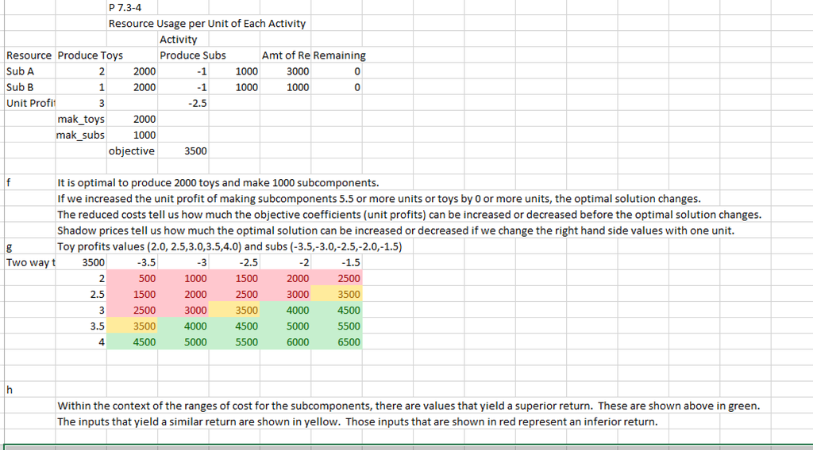

```python
from IPython.display import Image
Image(filename='7-3-4.png')
```

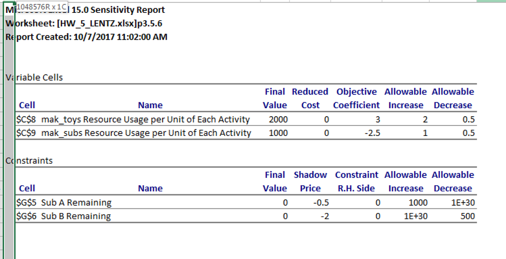

```python
from IPython.display import Image
Image(filename='7-3-4sens.png')
```

#### Problem 7.3-5 (a, b, f)

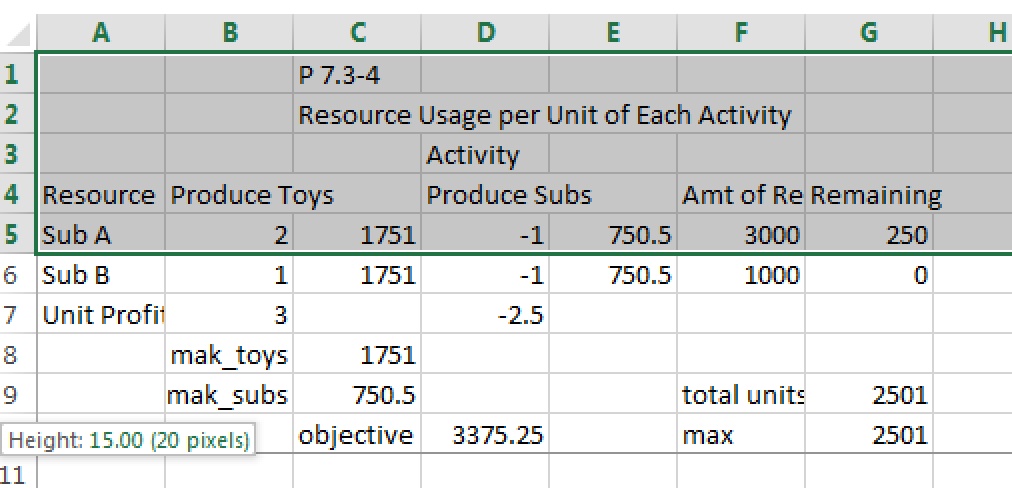

```python
from IPython.display import Image
Image(filename='7-3-5.png')
```

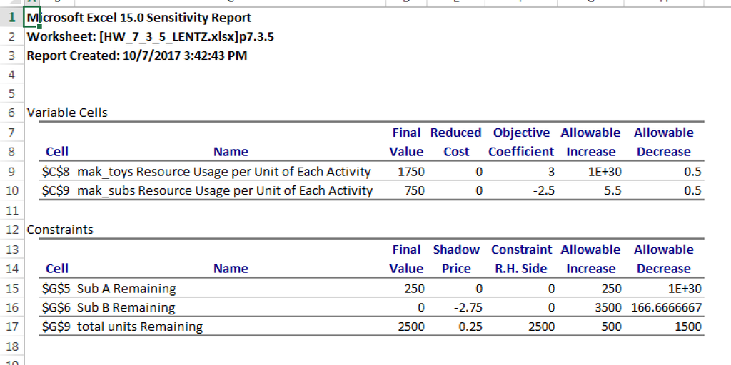

```python
from IPython.display import Image
Image(filename='7-3-5sens2500.png')
```

b) Therefore, unless the market will bear more than 2500 toys at a $3 per unit profit, we should not pay a premimum for part A and up to 2.5 for part B. As shown, the shadow prices tell us how much the items increase or decrease if we alter the RHS by one unit. Here we see that the shadow price is 0 for sub A and -2.75 for sub B due to the limiting constrain of 2500. This is the same for 2501, etc. until we exhaust the supply currently offered.

f) Therefore, unless the market will bear more than 2500 toys at a $3 per unit profit, we should not pay a premimum for part A and up to 2.5 for part B.

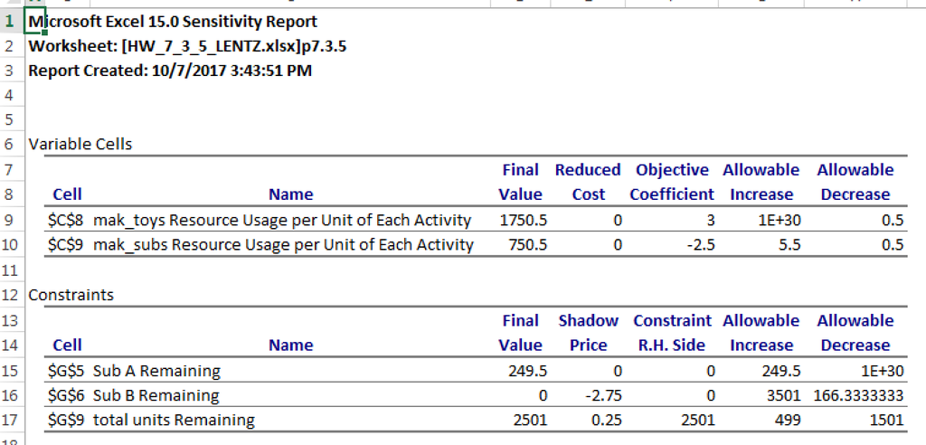

```python
from IPython.display import Image
Image(filename='7-3-5sens2501.png')
```

#### Problem 7.3-7 (a)

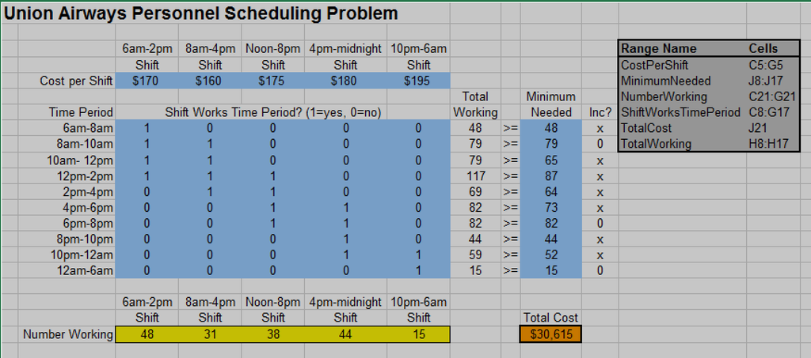

```python
from IPython.display import Image
Image(filename='7-3-7a.png')
```

Above we see the solver based Union Airways problem with the added sensitivity column (Inc?). Here an X means we can add without increasing Total Cost.

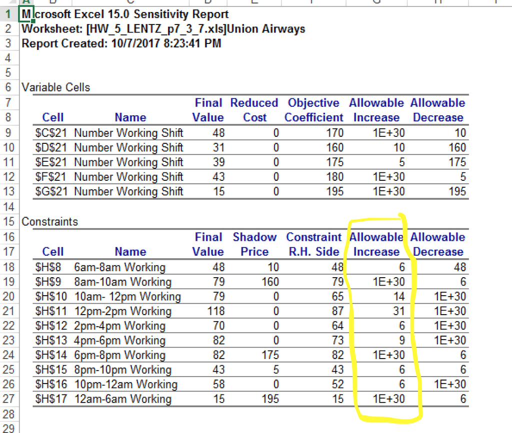

```python
from IPython.display import Image
Image(filename='7-3-7a_sens.png')
```

The above highlighted selection gives the range of the increase before the optimized Total Cost will be adversely impacted. This range reflects line management's operational model flexibility. Note, the three 1E+30s here mean that the shift cannot have any increase in 'Minimum number of Agents Needed' without impacting Total Cost.

#### Problem 7.4-4

```python
from pulp import *

prob = LpProblem("p7.4-4a", LpMaximize)

# The estimates and ranges of uncertainty for the uncertain parameters are
# defined in the next block.
a11 = 4
a22 = -1
a33 = 3
b1 = 30
b2 = 20
c2 = -8
c3 = 4

# Variables, lower bounds added here
x1 = LpVariable("x1",lowBound=0)
x2 = LpVariable("x2",lowBound=0)
x3 = LpVariable("x3",lowBound=0)

z = LpVariable("z", 0)

# Objective
prob += 5*x1 + c2*x2 + c3*x3

# Constraints
prob += a11*x1 -3*x2 + 2*x3 <= b1 # resource 1
prob += 3*x1 + a22*x2 + x3 <= b2 # resource 2
prob += 2*x1 -4*x2 + a33 * x3 <= 20 # resource 3

# Solve using GLPK
GLPK().solve(prob)

# Solution
for v in prob.variables():
    print (v.name, "=", v.varValue)

print ("objective=", value(prob.objective) )
```

```
('x1', '=', 5.71429)
('x2', '=', 0.0)
('x3', '=', 2.85714)
('objective=', 40.000009999999996)
```

a) The below output indicates the objective value and the values for x1, x2, and x3

('x1', '=', 5.71429) ('x2', '=', 0.0) ('x3', '=', 2.85714) ('objective=', 40.000009999999996)

```python
from pulp import *
import numpy as np
import datetime
from functools import reduce
from operator import mul
import math


how_many_minutes_we_can_wait = 1
characterized_performance_ops = 36000
number_of_parameter_dimensions = 7
steps_per_range = math.pow( (how_many_minutes_we_can_wait * characterized_performance_ops), 1/number_of_parameter_dimensions)

# if using distributions, random selection, and time
now = datetime.datetime.now()
stop_time = now + datetime.timedelta(minutes=1)

max_objective_value = float("-Inf")

a11_best = 0.0
a22_best = 0.0
a33_best = 0.0
b1_best = 0.0
b2_best = 0.0
c2_best = 0.0
c3_best = 0.0

a11_range = np.linspace(3.6, 4.4, num=math.floor(steps_per_range))
a22_range = np.linspace(-1.4, -0.6, num=math.floor(steps_per_range))
a33_range = np.linspace(2.5, 3.5, num=math.floor(steps_per_range))
b1_range = np.linspace(27.0, 33.0, num=math.floor(steps_per_range))
b2_range = np.linspace(19.0, 22.0, num=math.floor(steps_per_range))
c2_range = np.linspace(-9.0, -7.0, num=math.floor(steps_per_range))
c3_range = np.linspace(3.0, 5.0, num=math.floor(steps_per_range))

# this is okay if we can use huerisitics
# a11_range = np.arange(3.6, 4.4, 0.1)
# a22_range = np.arange(-1.4, -0.6, 0.1)
# a33_range = np.arange(2.5, 3.5, 0.1)
# b1_range = np.arange(27.0, 33.0, 0.1)
# b2_range = np.arange(19.0, 22.0, 0.1)
# c2_range = np.arange(-9.0, -7.0, 0.1)
# c3_range = np.arange(3.0, 5.0, 0.1)

parameter_optimization_ranges = [a11_range, a22_range, a33_range, b1_range, b2_range, c2_range, c3_range]
# total_operations_count = reduce(mul, [ len(rng) for rng in parameter_optimization_ranges], 1)
# print("this will take " + str(total_operations_count/36000) + " minutes.")
# exit()

counter = 0

# Variables, lower bounds added here
x1 = LpVariable("x1",lowBound=0)
x2 = LpVariable("x2",lowBound=0)
x3 = LpVariable("x3",lowBound=0)

z = LpVariable("z", 0)

# loop over parameter ranges
for a11 in a11_range:
    for a22 in a22_range:
        for a33 in a33_range:
            for b1 in b1_range:
                for b2 in b2_range:
                    for c2 in c2_range:
                        for c3 in c3_range:
                            counter = counter + 1

                            prob = LpProblem("p7.4-4b", LpMaximize)

                            # Objective
                            prob += 5*x1 + c2*x2 + c3*x3

                            # Constraints
                            prob += a11*x1 -3*x2 + 2*x3 <= b1 # resource 1
                            prob += 3*x1 + a22*x2 + x3 <= b2 # resource 2
                            prob += 2*x1 -4*x2 + a33 * x3 <= 20 # resource 3

                            # Solve using GLPK
                            GLPK().solve(prob)

                            # If solution is better, update best parameters
                            if value(prob.objective) > max_objective_value:
                                max_objective_value = value(prob.objective)
                                a11_best = a11
                                a22_best = a22
                                a33_best = a33
                                b1_best = b1
                                b2_best = b2
                                c2_best = c2
                                c3_best = c3

                #if datetime.datetime.now() >= stop_time:
                #    print(counter)
                #    exit()


# from multiprocessing import Pool
# if __name__ == '__main__':

#     p = Pool(8)
#     p.map(a3dProcess,subject_uuids_list)

# Solve solution again with best parameters
a11 = a11_best
a22 = a22_best
a33 = a33_best
b1 = b1_best
b2 = b2_best
c2 = c2_best
c3 = c3_best
print("Solving with optimum parameters: ")
print("a11 " + str(a11))
print("a22 " + str(a22))
print("a33 " + str(a33))
print("b1 " + str(b1))
print("b2 " + str(b2))
print("c2 " + str(c2))
print("c3 " + str(c3))

for v in prob.variables():
    print (v.name, "=", v.varValue)

print ("objective=", value(prob.objective) )
```

[output not shown]

b) For the robust optimization, I used naive search over the parameter space and a simple computational estimate was used to define paramater range specificity. Here are the robust optimal results, z ~= 200.0:

x1 = 0.0  
x2 = 15428400.0  
x3 = 21599800.0

objective= 200.0

#### Problem 7.5-1 - Effect of reduced standard deviation of chance constraints on total profit

```python
from pulp import *
prob = LpProblem("p7.5-1a", LpMaximize)  # a.k.a Wyndor Glass Co.

# Variables, lower bounds added here
x1 = LpVariable("x1",lowBound=0)
x2 = LpVariable("x2",lowBound=0)
z = LpVariable("z", 0)

# Objective
prob += 3*x1 + 2*x2, "Objective"

# Chance Constraints (RHS)
# b1 = 4
# b2 = 12
# b3 = 18

# z_score = 1.645
# #    =  mean - critical value * std_dev
# b1 = 4 - z_score * (.2)
# b2 = 12 - z_score * (.5)
# b3 = 18 - z_score * (.1)


# print("RHS before refinement: " )
# print("z_score " + str(z_score))
# print("b1 "+ str(b1))
# print("b2 "+ str(b2))
# print("b3 "+ str(b3))

z_score = 2.326
#  =  mean - critical value * std_dev
b1 = 4 - z_score * (.1)
b2 = 12 - z_score * (.25)
b3 = 18 - z_score * (.5)

print("RHS after refinement of estimates: " + str(z_score))
print("b1 "+ str(b1))
print("b2 "+ str(b2))
print("b3 "+ str(b3))

# Constraints
prob += x1 <= b1 , "constraint 1"
prob += 2*x2 <= b2 , "constraint 2"
prob += 3*x1 +2*x2 <= b3 , "constraint 3"


# Solve the optimization problem using the specified Solver
GLPK().solve(prob)

# Solution
print ("Status:", LpStatus[prob.status])
for v in prob.variables():
    print (v.name, "=", v.varValue)

print ("objective=", value(prob.objective) )
```

```
RHS after refinement of estimates: 2.326
b1 3.7674
b2 11.4185
b3 16.837
('Status:', 'Optimal')
('x1', '=', 3.7674)
('x2', '=', 2.7674)
('objective=', 16.837)
```

a) Deterministic equivalents of change constraints before...

RHS before refinement:  
z_score 1.645  
b1 3.671  
b2 11.1775  
b3 17.8355  
('Status:', 'Optimal')  
('x1', '=', 3.671)  
('x2', '=', 3.41125)  
('objective=', 17.8355)

and deterministic equivalents of change constraints after refinement:

RHS after refinement of estimates: 2.326  
b1 3.7674  
b2 11.4185  
b3 16.837  
('Status:', 'Optimal')  
('x1', '=', 3.7674)  
('x2', '=', 2.7674)  
('objective=', 16.837)

b) The total profit is estimated to decrease (17.84 - 16.837) ~= 1 unit based on the refined estimates in increased alpha level.

#### Problem 7.5-4 - Effect of mutually independent normal distributions on optimization

```python
from pulp import *
import scipy.stats as st
prob = LpProblem("p7.5-4", LpMaximize)

# Variables, lower bounds added here
x1 = LpVariable("x1",lowBound=0)
x2 = LpVariable("x2",lowBound=0)
x3 = LpVariable("x3",lowBound=0)
z = LpVariable("z", 0)

# Objective
prob += 20*x1 + 30*x2 + 25*x3, "Objective"

z_score_b1 = st.norm.ppf(.975)
z_score_b2 = st.norm.ppf(.95)
z_score_b3 = st.norm.ppf(.90)
#  =  mean - critical value * std_dev
b1 = 90 - z_score_b1 * (3)
b2 = 150 - z_score_b2 * (6)
b3 = 180 - z_score_b3 * (9)

print("RHS: ")
print("b1 "+ str(b1))
print("b2 "+ str(b2))
print("b3 "+ str(b3))

# Constraints
prob += 3*x1 + 2*x2 + 1*x3 <= b1 , "constraint 1"
prob += 2*x1 + 4*x2 + 2*x3 <= b2 , "constraint 2"
prob += 1*x1 + 3*x2 + 5*x3 <= b3 , "constraint 3"


# Solve the optimization problem using the specified Solver
GLPK().solve(prob)

# Solution
print ("Status:", LpStatus[prob.status])
for v in prob.variables():
    print (v.name, "=", v.varValue)

print ("objective=", value(prob.objective) )

# part a
x1 = 7
x2 = 22
x3 = 19

# z_score = (obs - mean) / std
print(3*x1 + 2*x2 + 1*x3)
p_c1 = 1-st.norm.cdf(3*x1 + 2*x2 + 1*x3,90,3)
print( p_c1 )

print(2*x1 + 4*x2 + 2*x3)

p_c2 =  1-st.norm.cdf(2*x1 + 4*x2 + 2*x3,150,6)
print( p_c2 )

print(1*x1 + 3*x2 + 5*x3)
p_c3 = 1-st.norm.cdf(1*x1 + 3*x2 + 5*x3,180,9)
print( p_c3 )

print("A: Overall p = p(c1)*p(c2)*p(c3) : "+ str(p_c1*p_c2*p_c3))


# part c
x1 = 7.02733
x2 = 21.9645
x3 = 19.109

print(3*x1 + 2*x2 + 1*x3)
p_c1 = 1-st.norm.cdf(3*x1 + 2*x2 + 1*x3,90,3)
print( p_c1 )


print(2*x1 + 4*x2 + 2*x3)
p_c2 = 1-st.norm.cdf(2*x1 + 4*x2 + 2*x3,150,6)
print( p_c2 )


print(1*x1 + 3*x2 + 5*x3)
p_c3 = 1-st.norm.cdf(1*x1 + 3*x2 + 5*x3,180,9)
print( p_c3 )

print("C: Overall p = p(c1)*p(c2)*p(c3) : "+ str(p_c1*p_c2*p_c3))
```

```
RHS:
b1 84.1201080464
b2 140.130878238
b3 168.46603591
('Status:', 'Optimal')
('x1', '=', 7.02733)
('x2', '=', 21.9645)
('x3', '=', 19.109)
('objective=', 1277.2066)
84
0.977249868052
140
0.952209647727
168
0.908788780274
A: Overall p = p(c1)*p(c2)*p(c3) : 0.845670448283
84.11999
0.975002299654
140.13066
0.950003751245
168.46583
0.90000401515
C: Overall p = p(c1)*p(c2)*p(c3) : 0.833633976986
```

a) $$ p(c1) = {0.977249868052} $$

$$ p(c2) = {0.952209647727} $$$$ p(c3) = {0.908788780274} $$

Overall prob, part a: $$ p(c1)*p(c2)*p(c3) = 0.845670448283 $$ b)

RHS: b1 84.1201080464  
b2 140.130878238  
b3 168.46603591

Results:  
('Status:', 'Optimal')  
('x1', '=', 7.02733)  
('x2', '=', 21.9645)  
('x3', '=', 19.109)  
('objective=', 1277.2066)

c)
$$p(c1) = {0.975002299654}$$

$$p(c2) = {0.950003751245}$$$$p(c3) = {0.90000401515}$$

Overall $$ p = p(c1)*p(c2)*p(c3) = 0.833633976986 $$

#### Problem 7.6-1

```python
from pulp import *
prob = LpProblem("p7.5-1a", LpMaximize)  #

# Variables, lower bounds added here
x1 = LpVariable("x1",lowBound=0)
x21 = LpVariable("x21",lowBound=0)
x22 = LpVariable("x22",lowBound=0)
z = LpVariable("z", 0)

# Objective
p_sitation_1 = .5
p_situation_2 = .5

prob += p_sitation_1*(3*x1 + 5*x21) + p_situation_2*(3*x1 + 1*x22), "Objective"


b1 = 4
b2 = 12
b3 = 18

# Constraints
prob += x1 <= b1 , "plant constraint 1"
prob += 2*x21 <= b2 , "plant constraint 2 sit 1"
prob += 2*x22 <= b2 , "plant constraint 2 sit 2"
prob += 3*x1 +2*x21 <= b3, "plant constraint 3 sit 1"
prob += 3*x1 +6*x22 <= b3, "plant constraint 3 sit 2"
# Solve the optimization problem using the specified Solver
GLPK().solve(prob)

# Solution
print ("Status:", LpStatus[prob.status])
for v in prob.variables():
    print (v.name, "=", v.varValue)

print ("objective=", value(prob.objective) )
```

```
('Status:', 'Optimal')
('x1', '=', 2.0)
('x21', '=', 6.0)
('x22', '=', 2.0)
('objective=', 22.0)
```

Let's compare the objective results between the prior belief state, where Scenario Two has a probability of 0.75 and the current belief state, where we have updated information stating that the scenarios are equally likely.

p(S2) = .75, p(S1) = .25 ('Status:', 'Optimal')  
('x1', '=', 4.0)  
('x21', '=', 3.0)  
('x22', '=', 1.0)  
('objective=', 16.5)

p(S2) = p(S1) = .5 ('Status:', 'Optimal')  
('x1', '=', 2.0)  
('x21', '=', 6.0)  
('x22', '=', 2.0)  
('objective=', 22.0)

We can see that the adverse effects of Scenario Two are reduced as the probability of that event decrease from .75 to .50. Intuitively, this makes sense since more competition results in a lower price and other needed changes that reduce profitability. Thus a reduction in the factor for the adverse event allow an increase in the objective using stochastic programming.

#### Problem 7.6-3

```python
from pulp import *
prob = LpProblem("p7.6-3", LpMaximize)  #

# Variables, lower bounds added here
x1 = LpVariable("test_market_advert",lowBound=5,upBound=10)
x21 = LpVariable("national_market_advert_vf",lowBound=0)
x22 = LpVariable("national_market_advert_bf",lowBound=0)
x23 = LpVariable("national_market_advert_uf",lowBound=0)
z = LpVariable("z", 0)

# Objective
p_very_favorable = .25
p_barely_favorable = .25
p_unfavorable = .5

prob += .5*(x1) + p_very_favorable*( 2*x21 ) + p_barely_favorable*( 0.2*x22 ) + p_unfavorable*( 0*x23 ), "Objective"


# Constraints
prob += x21 + x22 + x23 + x21 <= 100 , "plant constraint 1"

# Solve the optimization problem using the specified Solver
GLPK().solve(prob)

# Solution
print ("Status:", LpStatus[prob.status])
for v in prob.variables():
    print (v.name, "=", v.varValue)

print ("objective=", value(prob.objective) )
```

```
('Status:', 'Optimal')
('national_market_advert_bf', '=', 0.0)
('national_market_advert_uf', '=', 0.0)
('national_market_advert_vf', '=', 50.0)
('test_market_advert', '=', 10.0)
('objective=', 30.0)
```

10M should be spent in the test market and 50M should be spent nationally if the tests are very favorable. No money should be spent nationally if the tests are unfavorable or barely favorable.

The net cost is the objective profit of 30M less the fixed development costs of 40M or a loss of 10M. In a statistical sense, the company should not go ahead since the expected total net profit is negative 10M.